# Preço de apartamentos em São Paulo

O objetivo deste projeto é criar um modelo preditivo para preço de apartamentos na cidade de São Paulo. Os dados utilizados neste projeto foram capturas em Setembro de 2014 a partir de crawler que coletou informações existentes em diversos websites de imobiliárias.

Este dataset está sugeito a dados com erros. Por isso, faz parte deste projeto entender os dados, pré-processar e, se necessário, excluir exemplos que pareçam possuir informação errada.

## Leitura dos dados

Dados capturados em Setembro de 2014 a partir de websites de imobiliárias.

```r
load(file = '../data/20140917_imoveis_completo.rda')
class(imoveis)
```

```
## [1] "data.frame"
```

```r
names(imoveis)
```

```
## [1] "bairro"      "preco"       "area"        "suites"      "dormitorios"
## [6] "banheiros"   "descricao"   "vagas"
```

```r
nrow(imoveis)
```

```
## [1] 104560
```

```r
sapply(imoveis, class)
```

```
##      bairro       preco        area      suites dormitorios   banheiros
##    "factor"   "numeric"   "numeric"   "numeric"   "numeric"   "numeric"
##   descricao       vagas
## "character"   "numeric"
```

Exclusão de atributo em formato texto de difícil manipulação e aparentemente irrelevante.

```r
imoveis$descricao <- NULL
```

Análise da variável **bairro**

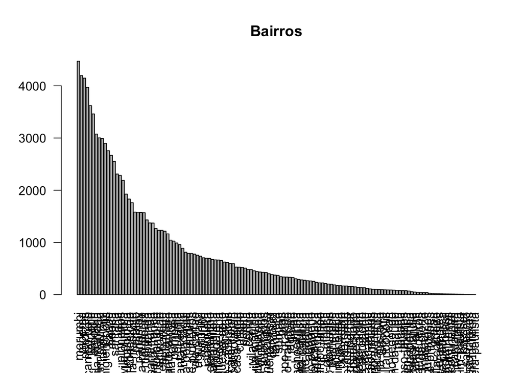

```r
barplot(sort(table(imoveis$bairro), decreasing = TRUE), las=2, main="Bairros")
```

```r
sort(table(imoveis$bairro), decreasing = TRUE)
```

```
##
##               morumbi                 moema              perdizes
##                  4473                  4197                  4148
##            campo-belo               tatuape              brooklin
##                  3973                  3620                  3461
##          vila-mariana       jardim-paulista            itaim-bibi
##                  3076                  3003                  2991
##          higienopolis                 saude                 mooca
##                  2899                  2757                  2668
##               santana                  lapa             pinheiros
##                  2555                  2310                  2284
##          vila-olimpia       vila-leopoldina   vila-nova-conceicao
##                  2187                  1925                  1830
##          vila-mascote               paraiso               panamby
##                  1761                  1581                  1579
##         vila-prudente      jardim-marajoara              ipiranga
##                  1573                  1568                  1430
##           barra-funda  jardim-analia-franco chacara-santo-antonio
##                  1373                  1370                  1267
##             aclimacao           real-parque            bela-vista
##                  1232                  1231                  1215
##           santo-amaro          vila-formosa               pompeia
##                  1163                  1043                  1024
##               butanta         santa-cecilia              mandaqui
##                   988                   958                   887
##     alto-da-boa-vista               jardins     alto-de-pinheiros
##                   811                   789                   787
##           vila-carrao             agua-rasa              tucuruvi
##                   775                   755                   736
##              pirituba             jabaquara       vila-clementino
##                   705                   697                   695
##        granja-julieta         vila-madalena          alto-da-lapa
##                   673                   665                   662
##        freguesia-do-o                sacoma      parque-sao-lucas
##                   654                   623                   615
##        chacara-klabin            consolacao            casa-verde
##                   594                   591                   526
##               cursino                 belem                 penha
##                   525                   523                   506
##                centro            vila-sonia          vila-matilde
```

[output cut: 36 more lines]

```
##                    67                    53                    48
##         vila-medeiros      jardim-da-gloria    ermelino-matarazzo
##                    43                    42                    40
##            guaianases  parque-dos-principes                grajau
##                    40                    25                    21
##         vila-cordeiro     cidade-tiradentes      cidade-patriarca
##                    17                    16                    15
##         jardim-brasil           parelheiros    parque-continental
##                    13                    12                    11
##            cantareira          city-butanta        itaim-paulista
##                    10                     8                     6
##               bresser      jardim-sao-bento     parque-edu-chaves
##                     5                     3                     3
##      jardim-lusitania      riviera-paulista
##                     2                     1
```

```r
length(table(imoveis$bairro))
```

```
## [1] 134
```

Análise da variável **preço**

```r
summary(imoveis$preco)
```

```
##     Min.  1st Qu.   Median     Mean  3rd Qu.     Max.
##        0   530000   850000  1293617  1456000 52000000
```

```r
nrow(imoveis[imoveis$preco == 0, ])
```

```
## [1] 4
```

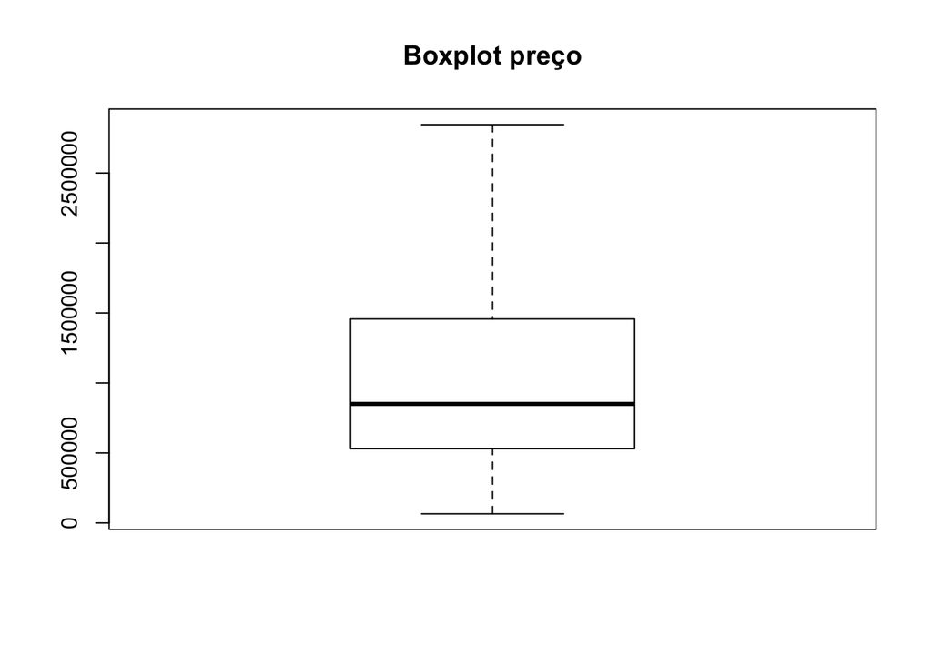

```r
imoveis <- imoveis[imoveis$preco > 0, ]
boxplot(imoveis$preco, outline = FALSE, main="Boxplot preço")
```

Exclusão de imóveis com preço superior a R$ 5.000.000,00

```r
nrow(imoveis[imoveis$preco > 5000000, ])
```

```
## [1] 2663
```

```r
imoveis <- imoveis[imoveis$preco < 5000000, ]
```

Análise da variável **área**, exclusão dos exemplos com valor faltante para área e exclusão dos exemplos com área menor que 10m2.

```r
summary(imoveis$area)
```

```
##    Min. 1st Qu.  Median    Mean 3rd Qu.    Max.    NA's
##     1.0    70.0   105.0   129.3   164.0   980.0      15
```

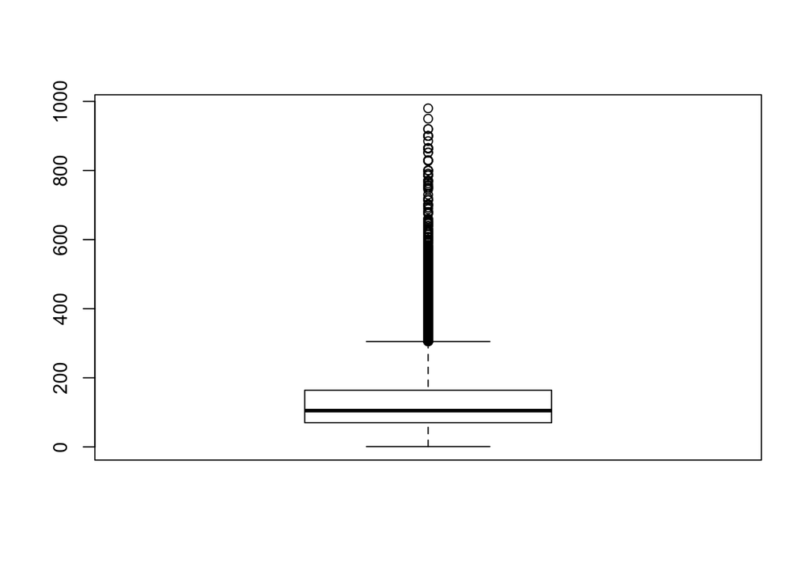

```r
imoveis <- imoveis[complete.cases(imoveis$area), ]
boxplot(imoveis$area)
```

```r
imoveis[imoveis$area < 10, c('area','preco','bairro')]
```

```
##         area   preco          bairro
## 913    2.180 1337000           mooca
## 3399   1.000 1400000        itaquera
## 16006  1.200 1500000    campo-grande
## 19018  1.000  600000      consolacao
## 21309  1.200 3600000         socorro
## 24828  1.000 3200000    cidade-dutra
## 26902  1.000 4900000      bela-vista
## 33714  1.350 1800000      interlagos
## 34033  1.214  800000      interlagos
## 36370  3.420 1620000     parelheiros
## 42936  1.025 4100000        ipiranga
## 43834  1.163 2400000        ipiranga
## 45250  2.016 1418000         cursino
## 46211  1.040 3800000         morumbi
## 46527  1.458 3500000         morumbi
## 63475  1.100 4300000      itaim-bibi
## 68109  1.102 1570000 jardim-paulista
## 69773  1.745 1745000 jardim-paulista
## 71407  1.000  300000        mandaqui
## 75854  6.180  320000        pirituba
## 78689  5.000  320000  freguesia-do-o
## 95623  1.000  750000        perdizes
## 103313 1.200 3800000          centro
```

```r
imoveis <- imoveis[imoveis$area > 10, ]
imoveis[imoveis$area < 20, c('area','preco','bairro','dormitorios')]
```

```
##          area   preco           bairro dormitorios
## 13301  15.000  310000    vila-prudente           2
## 18784  18.000  390000       consolacao           1
## 18894  18.000  390000       consolacao           1
## 19788  19.000 1311000 jardim-marajoara           3
## 47458  18.642  770000          morumbi           3
## 69629  15.000  260000  jardim-paulista           1
## 69775  18.000  250000  jardim-paulista           1
## 75361  19.000  460000         pirituba           3
## 80709  19.000  408600      barra-funda           1
## 87291  18.000  430000        pinheiros           1
## 96167  18.000  180000         perdizes           1
## 103091 18.000  220000           centro           1
## 103100 18.000  220000           centro           1
## 103119 18.000  320000           centro           1
## 103154 15.000  305000           centro           1
## 103183 18.000  165000           centro           1
## 103247 16.000  205000           centro           1
```

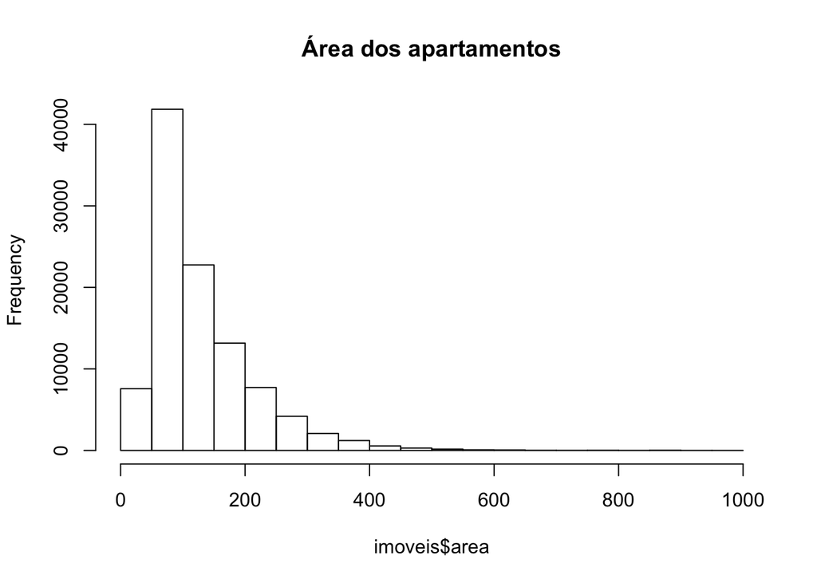

```r
hist(imoveis$area, main="Área dos apartamentos")
```

Análise da variável **dormitórios** e exclusão de exemplos com valores faltantes para dormitórios.

```r
summary(imoveis$dormitorios)
```

```
##    Min. 1st Qu.  Median    Mean 3rd Qu.    Max.    NA's
##    1.00    2.00    3.00    2.77    3.00   13.00     273
```

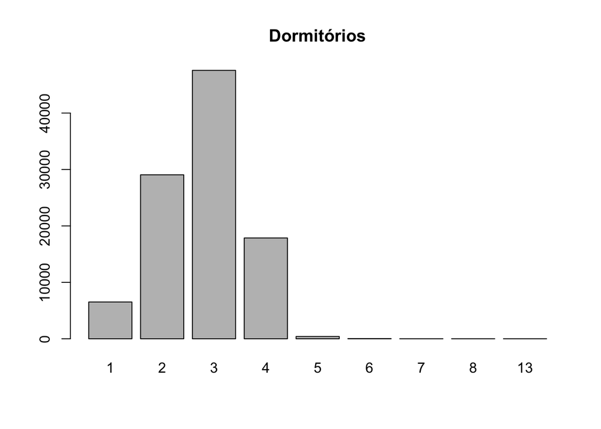

```r
imoveis <- imoveis[complete.cases(imoveis$dormitorios),]
barplot(table(imoveis$dormitorios), main="Dormitórios")
```

Análise da variável *banheiros* e exclusão de exemplos com valores faltantes para banheiros.

```r
summary(imoveis$banheiros)
```

```
##    Min. 1st Qu.  Median    Mean 3rd Qu.    Max.    NA's
##   1.000   1.000   2.000   2.643   4.000  99.000   17591
```

```r
imoveis <- imoveis[complete.cases(imoveis$banheiros), ]
table(imoveis$banheiros)
```

```
##
##     1     2     3     4     5     6     7     8     9    10    11    99
## 21666 24673 15869 10185  8048  2855   377   142    38     2     3     8
```

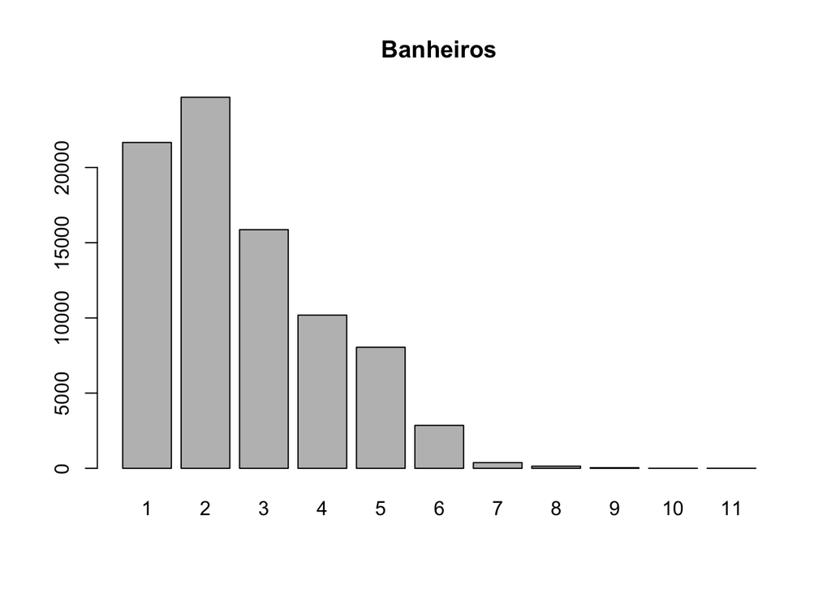

```r
imoveis <- imoveis[imoveis$banheiros < 15, ]
barplot(table(imoveis$banheiros), main="Banheiros")
```

Análise da variável **suites**

```r
summary(imoveis$suites)
```

```
##    Min. 1st Qu.  Median    Mean 3rd Qu.    Max.    NA's
##   1.000   1.000   1.000   1.736   3.000   9.000   20900
```

```r
imoveis$suites <- ifelse(is.na(imoveis$suites), 0, imoveis$suites)
table(imoveis$suites)
```

```
##
##     0     1     2     3     4     5     6     9
## 20900 37825  8819 11574  4605   130     4     1
```

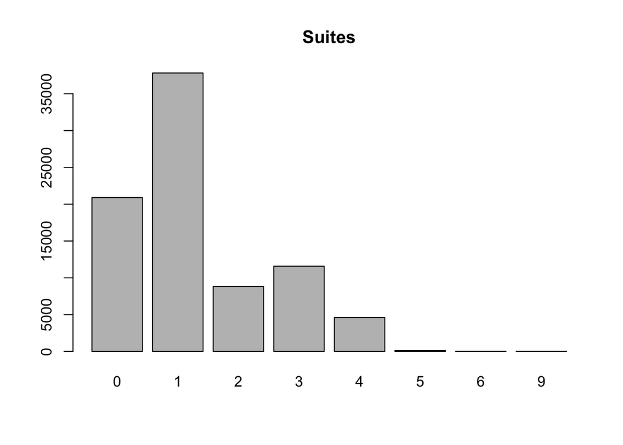

```r
barplot(table(imoveis$suites), main="Suites")
```

Análise da variável **vagas**

```r
summary(imoveis$vagas)
```

```
##    Min. 1st Qu.  Median    Mean 3rd Qu.    Max.    NA's
##   0.000   1.000   2.000   2.017   3.000  34.000    3108
```

```r
imoveis$vagas <- ifelse(is.na(imoveis$vagas), 0, imoveis$vagas)
table(imoveis$vagas)
```

```
##
##     0     1     2     3     4     5     6     7     8     9    10    11
##  3122 32090 27566 11898  7030  1389   579   105    58     3    11     2
##    12    15    20    34
##     2     1     1     1
```

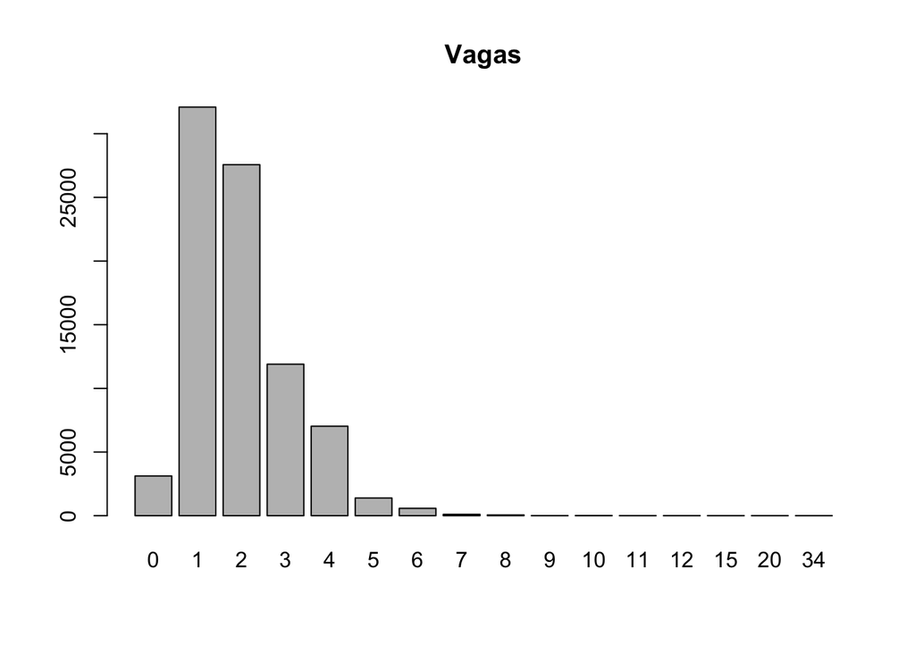

```r
barplot(table(imoveis$vagas), main="Vagas")
```

```r
nrow(imoveis)
```

```
## [1] 83858
```

```r
sum(is.na(imoveis))
```

```
## [1] 0
```

Vamos trabalhar apenas com apartamentos até 600m2.

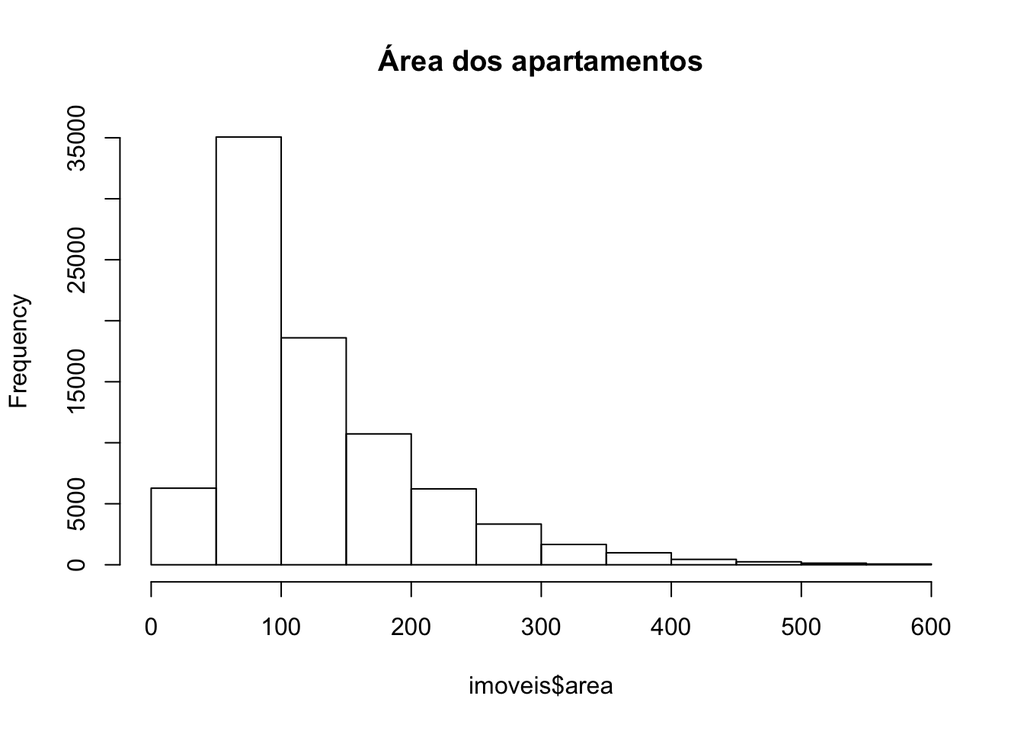

```r
imoveis <- imoveis[imoveis$area <= 600, ]
hist(imoveis$area, main="Área dos apartamentos")
```

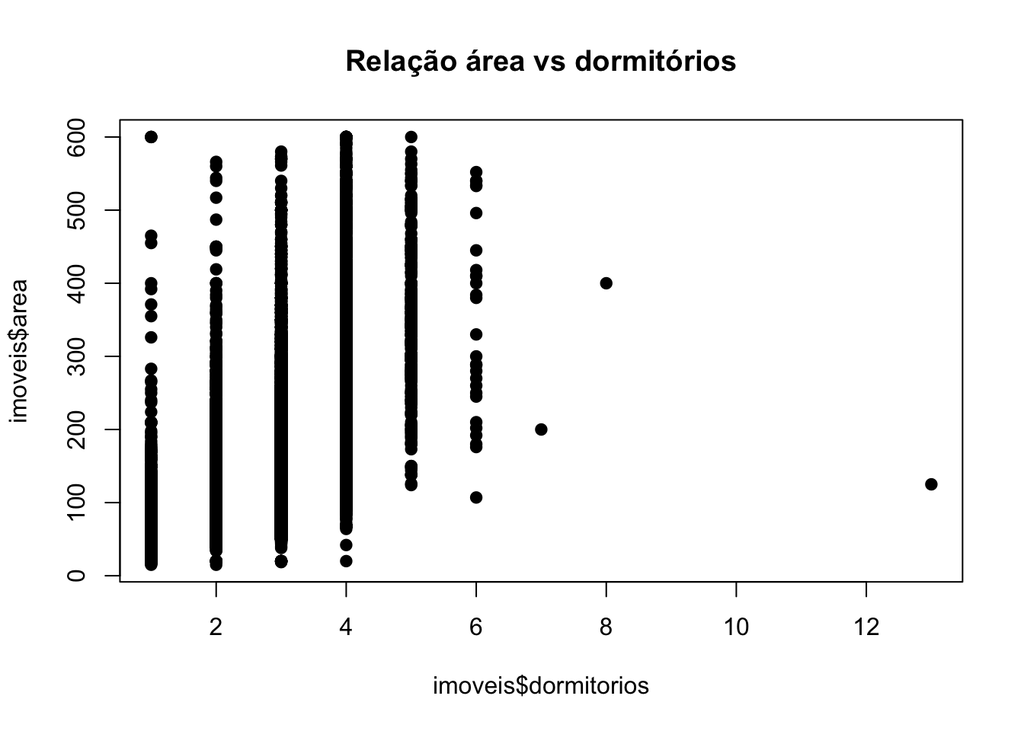

```r
plot(imoveis$area ~ imoveis$dormitorios, pch=19, main="Relação área vs dormitórios")
```

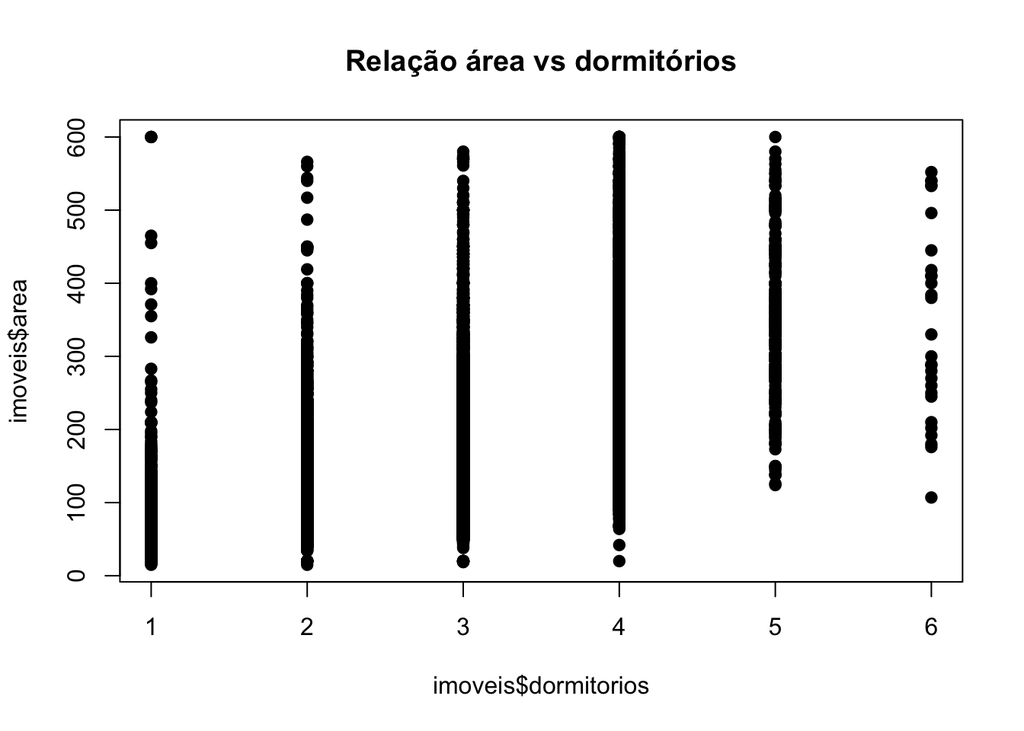

```r
imoveis <- imoveis[imoveis$dormitorios < 7, ]
plot(imoveis$area ~ imoveis$dormitorios, pch=19, main="Relação área vs dormitórios")
```

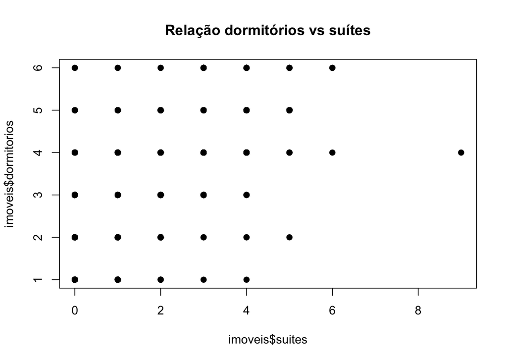

```r
plot(imoveis$dormitorios ~ imoveis$suites, pch=19, main="Relação dormitórios vs suítes")
```

Não podemos ter a quantidade de suites maior que a quantidade de dormitórios.

```r
sum(imoveis$suites <= imoveis$dormitorios)
```

```
## [1] 83722
```

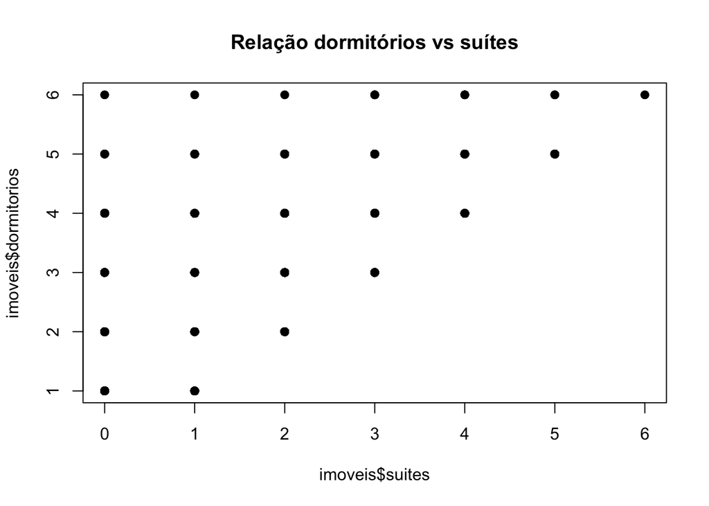

```r
imoveis <- imoveis[(imoveis$suites <= imoveis$dormitorios), ]
plot(imoveis$dormitorios ~ imoveis$suites, pch=19, main="Relação dormitórios vs suítes")
```

Excluindo apartamentos com mais de 10 banheiros com mais de 10 vagas.

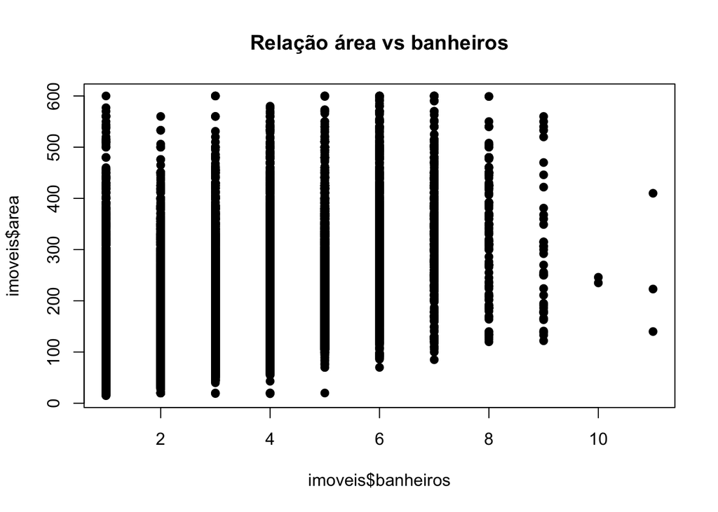

```r
plot(imoveis$area ~ imoveis$banheiros, pch=19, main="Relação área vs banheiros")
```

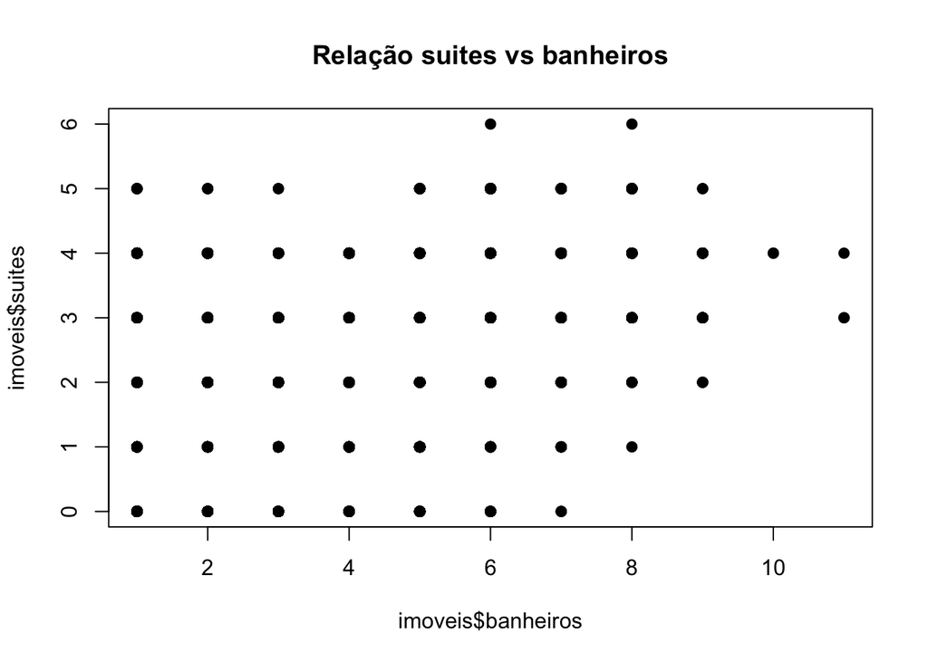

```r
plot(imoveis$suites ~ imoveis$banheiros, pch=19, main="Relação suites vs banheiros")
```

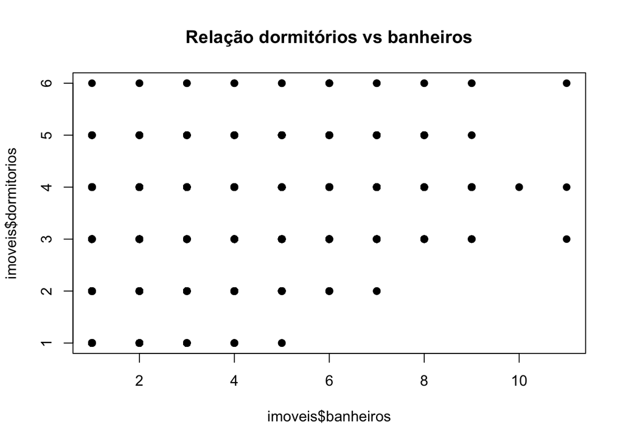

```r
plot(imoveis$dormitorios ~ imoveis$banheiros, pch=19, main="Relação dormitórios vs banheiros")
```

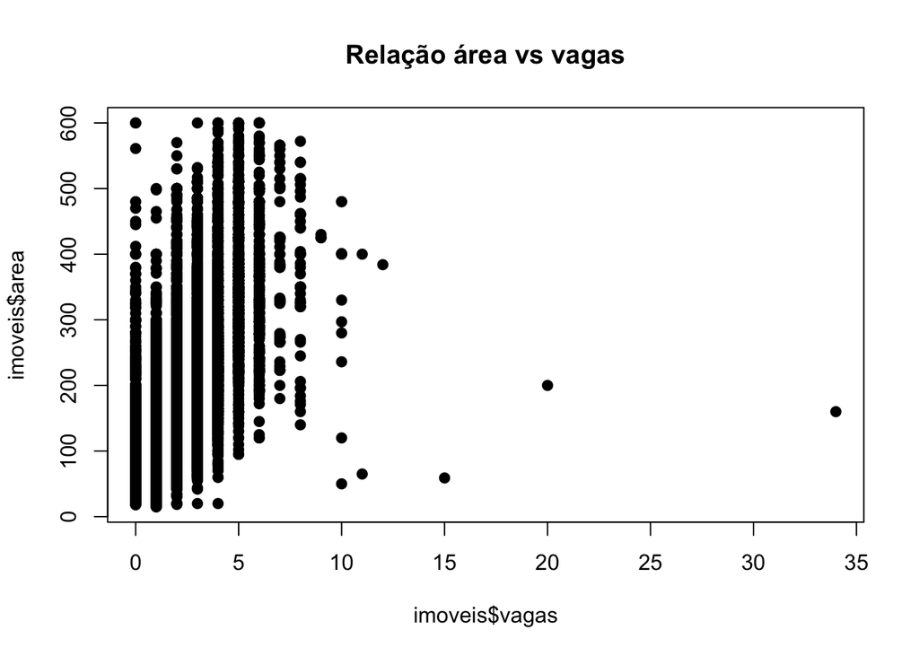

```r
imoveis <- imoveis[imoveis$banheiros < 10, ]

plot(imoveis$area ~ imoveis$vagas, pch=19, main="Relação área vs vagas")
```

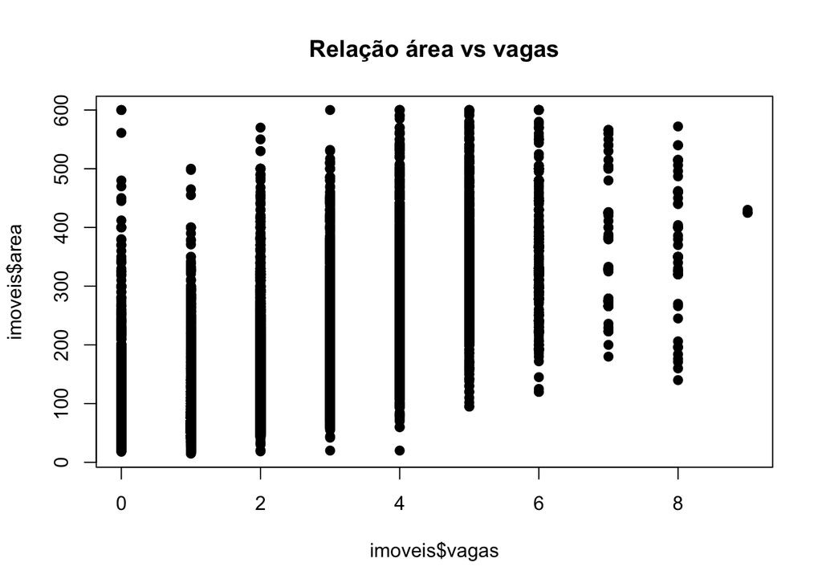

```r
imoveis <- imoveis[imoveis$vagas < 10, ]
plot(imoveis$area ~ imoveis$vagas, pch=19, main="Relação área vs vagas")
```

Apresentando outras formas de visualização

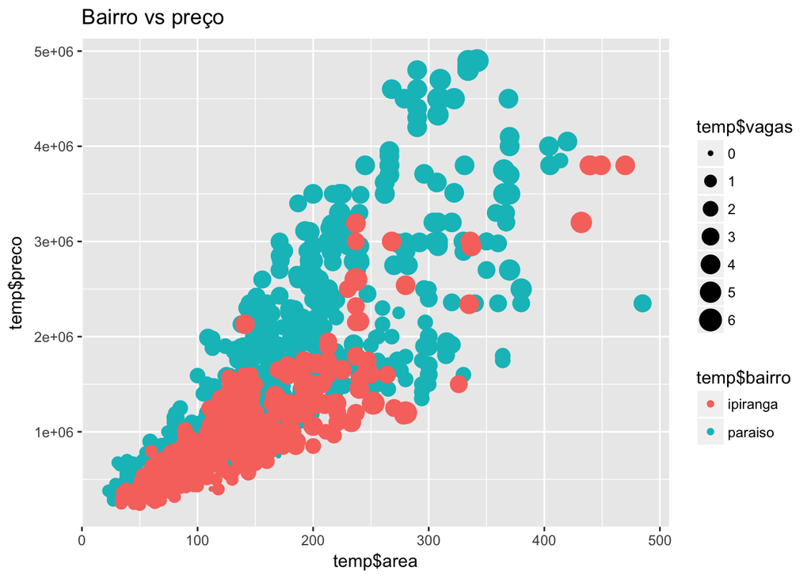

```r
library(ggplot2)
temp <- imoveis[(imoveis$bairro == 'ipiranga' | imoveis$bairro == 'paraiso'), ]
qplot(temp$area, temp$preco, col=temp$bairro, size=temp$vagas, main = "Bairro vs preço")
```

Apresentando a correlação entre as variáveis numéricas

```r
cor(imoveis[, 2:7])
```

```
##                 preco      area    suites dormitorios banheiros     vagas
## preco       1.0000000 0.8439373 0.6978029   0.5396327 0.6343616 0.7086896
## area        0.8439373 1.0000000 0.7119578   0.6586128 0.6786000 0.7499219
## suites      0.6978029 0.7119578 1.0000000   0.6035115 0.7497774 0.7596730
## dormitorios 0.5396327 0.6586128 0.6035115   1.0000000 0.6115375 0.6049046
## banheiros   0.6343616 0.6786000 0.7497774   0.6115375 1.0000000 0.6705960
## vagas       0.7086896 0.7499219 0.7596730   0.6049046 0.6705960 1.0000000
```

```r
imoveis <- imoveis[imoveis$bairro != 'city-butanta', ]
imoveis <- imoveis[imoveis$bairro != 'cantareira', ]
imoveis <- imoveis[imoveis$bairro != 'parelheiros', ]
imoveis <- imoveis[imoveis$bairro != 'parque-continental', ]
imoveis <- imoveis[imoveis$bairro != 'itaim-paulista', ]
imoveis <- imoveis[imoveis$bairro != 'bresser', ]
imoveis <- imoveis[imoveis$bairro != 'jardim-sao-bento', ]
imoveis <- imoveis[imoveis$bairro != 'parque-edu-chaves', ]
imoveis <- imoveis[imoveis$bairro != 'jardim-lusitania', ]
imoveis <- imoveis[imoveis$bairro != 'riviera-paulista', ]
imoveis <- imoveis[imoveis$bairro != 'city-butanta', ]
imoveis$bairro <- factor(imoveis$bairro)
sort(table(imoveis$bairro), decreasing = TRUE)
```

```
##
##               morumbi              perdizes               tatuape
##                  3674                  3122                  3104
##            campo-belo                 moema              brooklin
##                  3037                  2914                  2619
##          vila-mariana          higienopolis                 mooca
##                  2440                  2351                  2341
##               santana                 saude       jardim-paulista
##                  2239                  2196                  2177
##            itaim-bibi             pinheiros                  lapa
##                  2120                  1778                  1724
##          vila-olimpia       vila-leopoldina          vila-mascote
##                  1657                  1560                  1467
##         vila-prudente      jardim-marajoara               panamby
##                  1456                  1352                  1331
##               paraiso              ipiranga  jardim-analia-franco
##                  1182                  1165                  1157
##           real-parque chacara-santo-antonio           barra-funda
##                  1024                  1003                   996
##   vila-nova-conceicao            bela-vista             aclimacao
##                   972                   967                   961
##          vila-formosa           santo-amaro               pompeia
##                   910                   840                   817
##              mandaqui         santa-cecilia               butanta
##                   801                   777                   712
##           vila-carrao              tucuruvi     alto-da-boa-vista
##                   712                   685                   675
##             agua-rasa             jabaquara              pirituba
##                   663                   620                   620
##      parque-sao-lucas               jardins       vila-clementino
##                   580                   578                   571
##     alto-de-pinheiros        granja-julieta        freguesia-do-o
##                   569                   558                   550
##          alto-da-lapa         vila-madalena                sacoma
##                   549                   548                   529
##            consolacao               cursino                 penha
##                   516                   489                   485
##            casa-verde          vila-matilde                 belem
##                   465                   428                   421
##        chacara-klabin                centro            vila-sonia
```

[output cut: 30 more lines]

```
##                    76                    75                    75
##        raposo-tavares         chacara-flora                jacana
##                    73                    71                    71
##              pacaembu             sapopemba      vila-brasilandia
##                    71                    65                    49
##           artur-alvim    ermelino-matarazzo            guaianases
##                    47                    40                    36
##         vila-medeiros      jardim-da-gloria  parque-dos-principes
##                    36                    32                    23
##         cidade-jardim        jardim-america     cidade-tiradentes
##                    22                    20                    16
##      cidade-patriarca                grajau         jardim-brasil
##                    15                    15                    12
##         vila-cordeiro
##                    11
```